# 00. Main-text figures

Paper-figure assembler for the chromlearn project. Each section below produces one main-text figure (PDF + 600 dpi PNG) for the early-prometaphase spindle-force-inference manuscript. Forecast error vs horizon, per-cell breakdowns, and hyperparameter sensitivities sit in `00b_supplement.py`.

## Publication style

Shared matplotlib rcParams for all figures in this notebook. Targets a Cell/PNAS-style layout: sans-serif, 7-8 pt labels, vector PDF with embedded TrueType fonts (`pdf.fonttype = 42`) plus 600 dpi PNG.

## Setup: load data, fit selected model

Selected configuration: `poles_and_chroms` topology with steric envelope on the xx kernel (`r0 = 1.5 um`, `w = 0.3 um`), `n_basis = 10` and `lambda_rough = 1.0`. Bootstrap with 100 cell-level resamples for kernel CI bands.

```
Loaded 12 rpe18_ctr cells (frac=0.4).
```

```
Fitted selected model: D_x = 1.9709e-03 um^2/s, theta size = 20
```

```
[Parallel(n_jobs=-1)]: Using backend LokyBackend with 16 concurrent workers.
```

```
[Parallel(n_jobs=-1)]: Done  18 tasks      | elapsed:    6.6s
```

```
Chrom-chrom pair-distance 1%-quantile = 1.148 um (used to truncate xx kernel plots)
```

```
[Parallel(n_jobs=-1)]: Done 100 out of 100 | elapsed:   18.3s finished
```

## Fig 1. PCA trajectories and chromosome-pole lag correlation

```
Saved fig1_pca_lag.pdf and fig1_pca_lag.png
```

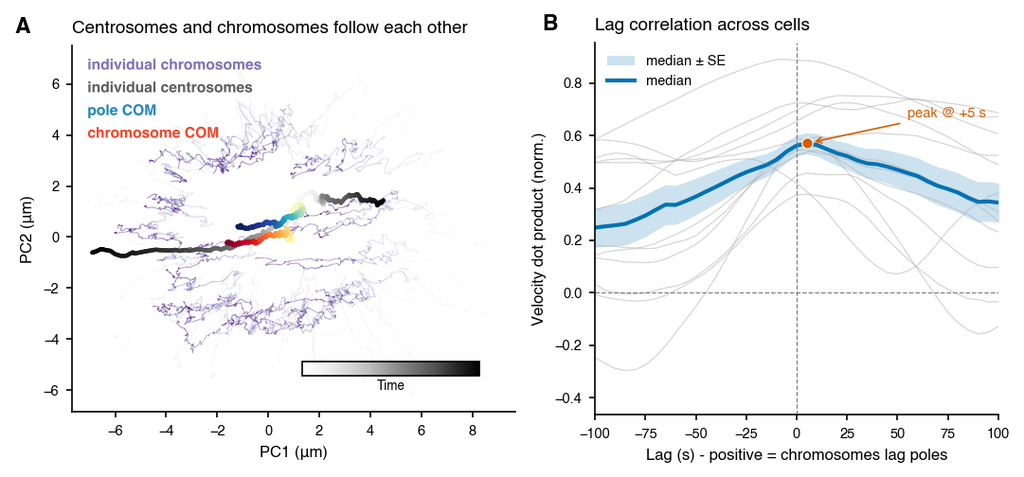

Fig 1. Chromosome center-of-mass motion lags pole center-of-mass motion during early prometaphase. (A) Example RPE-1 control cell projected into the spindle principal-axis frame, with individual chromosomes, both centrosomes, and chromosome and pole center-of-mass tracks shown over time. (B) Pooled lag correlation between pole-COM and chromosome-COM velocities across all cells; the positive-lag peak shows that chromosome motion follows pole motion.

## Fig 2. Pole motion is predicted from inter-pole interactions alone

```
Computing pp-only vs pp+cp vs cp-only LOO metrics...
```

```
  1-step RMSE  pp-only: 0.01922, pp+cp: 0.01899, cp-only: 0.01931 um/s
  Path MSE     pp-only: 16.216, pp+cp: 14.064, cp-only: 18.423 um^2
```

```
Bootstrapping pp-only, pp+cp, and cp-only kernels (n_boot=100)...
```

```
Fig 2 numerical summary
============================================================
1-step RMSE  (autonomous one-frame test):
  pp-only:  0.01922 +/- 0.00144 um/s
  pp+cp:    0.01899 +/- 0.00150 um/s
  delta:    +0.00023 +/- 0.00008    delta/SE = +3.03
  pp-only better in 2/12 cells

Path MSE  (deterministic rollout, real CHs given as covariates):
  pp-only:  16.22 +/- 2.68 um^2
  pp+cp:    14.06 +/- 2.88 um^2
  delta:    +2.15 +/- 0.63    delta/SE = +3.40
  pp-only better in 2/12 cells

Caveat: the path-MSE pp+cp edge reflects partition non-
identifiability — real chromosome positions enter the rollout
as covariates, so pp+cp absorbs CH-correlated noise without a
clean causal advantage; 1-step RMSE is the autonomous test.

cp-only:
  1-step RMSE: 0.01931 um/s
  Path MSE:    18.42 um^2
  cp-only is structurally insufficient — it cannot reproduce
  pole motion without an inter-pole term.  The (f_pp, f_cp)
  split inside the pp+cp model is non-identifiable (Fig S1).
```

```
Saved fig2_cs_sufficient.pdf and fig2_cs_sufficient.png
```

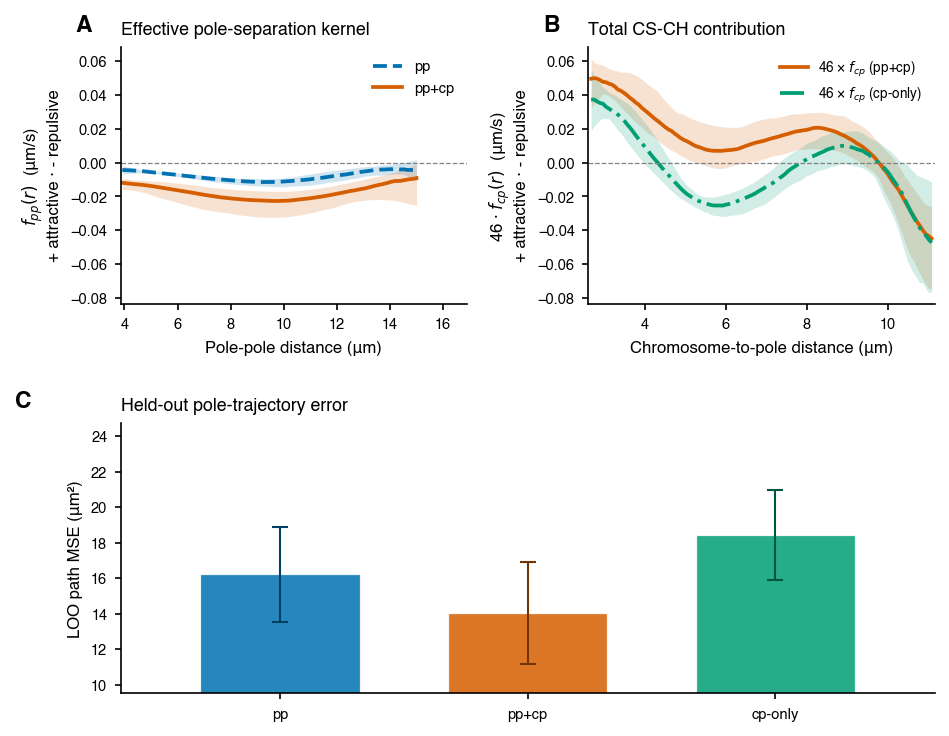

Fig 2. Pole motion is predicted from inter-pole interactions alone. (A) The effective pole-pole term f_pp(r), as a function of inter-pole distance, from the pole-velocity regression. Bands are 5-95 % bootstrap CI over cell-level resamples. (B) The chromosome-to-pole contribution scaled by the typical chromosome count, 46·f_cp(r), so the per-pair radial term is on the same scale as the single inter-pole interaction. The 46x value is not the actual chromosome contribution to pole velocity: chromosomes pull from many directions and partially cancel, while this curve sums radial magnitudes only. The f_pp / f_cp split inside the joint pp+cp fit is not separately identifiable; Fig S1 shows this directly. (C) Held-out path MSE from deterministic rollout (mean squared 3D pole-position error over the trimmed early-prometaphase window) for three pole-velocity models: inter-pole only (pp), inter-pole plus chromosome-to-pole (pp+cp), and chromosome-to-pole only (cp-only). pp and pp+cp are close, while cp-only cannot reproduce pole motion without an inter-pole term.

- Two complementary metrics are reported in the printed numerical summary: 1-step velocity RMSE (autonomous one-frame prediction) and path MSE (full deterministic rollout from the real initial frame). Both support the same qualitative conclusion once the pp/cp non-identifiability caveat is applied; path MSE is shown in panel C.
- The pp+cp rollout uses real held-out chromosome positions as covariates rather than co-simulating chromosomes. Its slightly lower path MSE reflects partition non-identifiability and chromosome- correlated noise fitting, not a clean causal advantage for pole- chromosome coupling.
- 46 is the typical chromosome count visible per cell in this condition. The 46x scaling in panel B sums the radial component of the per-chromosome contribution and ignores cancellation from the chromosomes' angular distribution around the pole, so it exceeds the actual chromosome contribution to pole velocity.
- The basis for both kernels is `BSplineBasis(R_MIN=0.3, R_MAX=15.0, n_basis=6)` with a roughness penalty `lambda_rough = 1.0` and numerical-jitter ridge `lambda_ridge = 1e-6`. The penalty scales are identical to the chromosome force model (Fig 3) so the same smoothness prior applies to both regressions.
- The pole-velocity regression is intentionally outside the `chromlearn.model_fitting` chromosome-dynamics pipeline, since here we are predicting pole motion rather than chromosome motion. The same trajectory data supports both regressions.

## Fig 3. Learned chromosome force kernels and topology selection

```
Fitting + bootstrapping topologies for Fig 3...
  fitting poles...
```

```
[Parallel(n_jobs=-1)]: Using backend LokyBackend with 16 concurrent workers.
```

```
[Parallel(n_jobs=-1)]: Done  18 tasks      | elapsed:    1.0s
```

```
[Parallel(n_jobs=-1)]: Done 100 out of 100 | elapsed:    3.6s finished
```

```
  fitting center...
```

```
[Parallel(n_jobs=-1)]: Using backend LokyBackend with 16 concurrent workers.
```

```
[Parallel(n_jobs=-1)]: Done  18 tasks      | elapsed:    0.8s
```

```
[Parallel(n_jobs=-1)]: Done 100 out of 100 | elapsed:    3.3s finished
```

```
  fitting poles_and_chroms...
```

```
[Parallel(n_jobs=-1)]: Using backend LokyBackend with 16 concurrent workers.
```

```
[Parallel(n_jobs=-1)]: Done  18 tasks      | elapsed:    5.3s
```

```
[Parallel(n_jobs=-1)]: Done 100 out of 100 | elapsed:   19.3s finished
```

```
Computing path MSE (rollout CV) for each topology...
  rollout-CV poles...
```

```
  rollout-CV center...
```

```
  rollout-CV poles_and_chroms...
```

```
  rollout-CV poles_and_chroms_enveloped...
```

```
Saved fig3_kernels_topology.pdf and fig3_kernels_topology.png
```

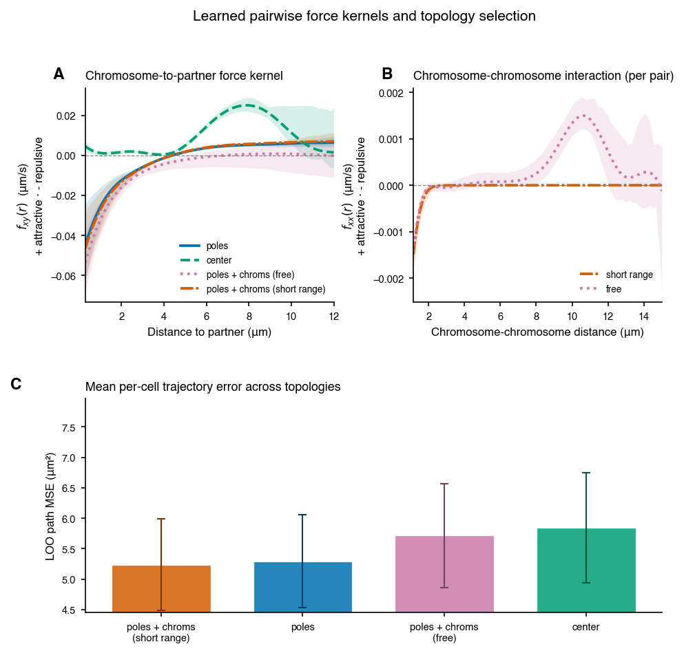

Fig 3. A short-range chromosome-chromosome prior removes the long-range f_xx artifact without sacrificing held-out trajectory accuracy; among the biologically admissible models, the short-range topology is selected by deterministic-rollout path MSE. (A) f_xy(r), the chromosome-to-partner radial force kernel, overlaid for four candidate topologies: chromosome attracted to nearest pole (poles), chromosome attracted to the spindle midpoint (center), poles plus chromosome-chromosome free (poles + chroms, free), and poles plus chromosome-chromosome enveloped (poles + chroms, short range). Bands are 5-95 % bootstrap CI. (B) f_xx(r), the chromosome- chromosome per-pair kernel, for the two topologies that include one. The short-range fit applies a smooth steric envelope `s(r) = 0.5 (1 - tanh((r - r0) / w))` with r0 = 1.5 um and w = 0.3 um, which suppresses the kernel beyond the contact regime. The free fit deviates from zero at long range, an artifact that motivates the envelope. The free topology is a flexible but biologically inadmissible upper bound, since long-range chromosome-chromosome forces have no known biological basis in mammalian mitosis. (C) Leave-one-cell-out deterministic-rollout path MSE for the same four topologies, sorted ascending; the short-range model is the selected biologically admissible topology.

## Fig 3b. Forward simulation reproduces observed gathering

```
Sim-vs-real cell: idx=0, id=rpe18_ctr_006, selected-topology path MSE = 1.97 um^2 (median 4.94)
  highlighted 14 chromosomes; displacement range 2.62-4.95 um; spread evenly along the spindle axis
```

```
Saved fig3b_sim_vs_real_pca.pdf and fig3b_sim_vs_real_pca.png
```

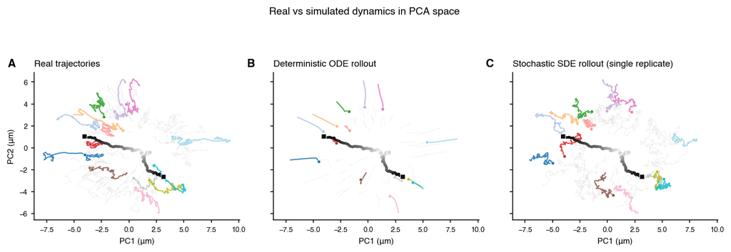

Fig 3b. The selected short-range model reproduces chromosome gathering when run forward from the real initial frame. Cell `rpe18_ctr_006` is shown, projected into a PCA basis fit from the cell's combined pole and chromosome point cloud. Left: real trajectories. Middle: deterministic ODE rollout under the fitted force kernels. Right: a single stochastic SDE replicate using diffusion coefficient D_x/2, splitting the fitted noise budget between intrinsic chromosome diffusion and localization/tracking error. Centrosomes are colored in greys (light to dark over time) with circle start and square end markers; chromosomes use one categorical color per chromosome, with no time encoding, so the eye can match individuals across panels.

- Cell selection: a cell with low LOO path MSE on the selected topology is chosen as a representative example. The same panels for other cells are qualitatively similar but visually noisier; the example here is meant to be readable, not best-case.
- The PCA basis is fit from the combined pole-plus-chromosome point cloud, then sign-aligned so PC1 lies along the pole-pole axis. No manual centering is applied.
- Why D_x/2 in the stochastic panel: the fitted scalar D absorbs both genuine chromosome diffusion and kinetochore localization / tracking noise. Splitting D evenly is a display convention that avoids assigning all fitted residual variance to intrinsic chromosome motion. Changing this split changes the visible stochastic spread but not the deterministic fitted force field.
- Only one SDE replicate is shown; multi-replicate ensemble means approach the ODE rollout. The point is to show that a single noisy realization remains visibly close to the data.
- Quantitative held-out comparisons live in Fig 3 panel C and Fig S2.

## Fig 4. Effective diffusion landscape and drift signal fraction

```
Plot range clipped to [1.07, 7.74] um (data support)
```

```
Trimmed-window length T_obs across cells: median 475 s, range [410, 630] s (reported for context only)
Main-panel reference timescale T_steady = 150 s (docx Result 1: steady-elongation phase ~ 2.5 min)
Computing f_drift(d; T_steady) and per-step Pe(d) at every observation...
```

```
  f_drift overall median: 0.536 (IQR [0.417, 0.610])
  per-step Pe median:     0.196
  bins with >= 30 obs:    18 of 18
```

```
Saved fig4_diffusion_landscape.pdf and fig4_diffusion_landscape.png
```

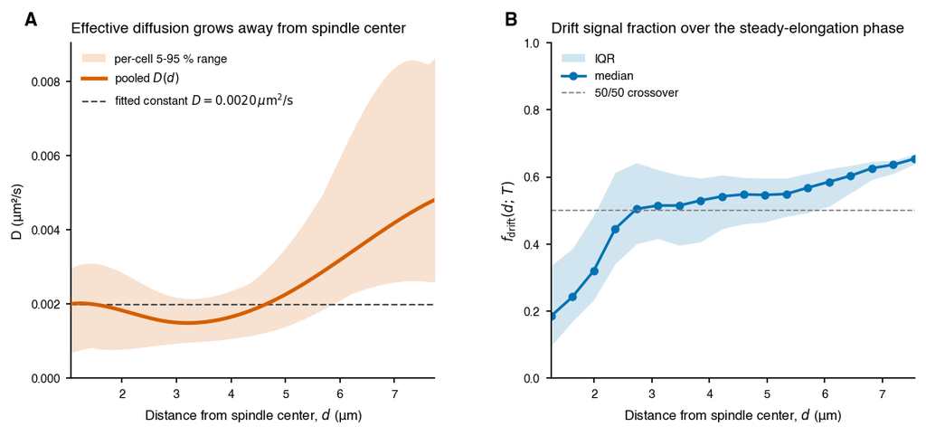

Fig 4. Drift outweighs diffusion across most of the spindle interior. (A) Effective diffusivity D(d), plotted against the chromosome's 3D distance d from the spindle center. The vermilion line is the pooled fit across all cells; the band spans the per-cell 5-95 % range; the dashed line is the fitted constant-D scalar for reference. D grows away from the spindle center, consistent with our previous report. (B) Local drift signal fraction f_drift(d; T) = |F(d)|^2 T / (|F(d)|^2 T + 2 D(d)), the fraction of a chromosome's motion attributable to the inferred force F(d) rather than to random diffusion D(d), accumulated over a time window T. f_drift = 0.5 is the crossover at which the squared distance traveled under the drift force equals the variance accumulated by diffusion over T. T = 150 s is the duration of the steady spindle-elongation phase reported in Result 1 ("the elongation rate remains remarkably constant for ~ 2.5 min"). Solid line is the bin median; band is IQR. Sensitivity to T is in Fig S5.

- D(d) is estimated as a second stage with the force field held fixed: residual displacements after subtracting the fitted drift, averaged in distance bins and divided by 2 dt. Subtracting the drift first removes the contamination that would otherwise bias a plain mean-squared-displacement estimator in this drift-dominated setting.
- Default fits use the Itô convention. When D depends on position, the Itô vs Stratonovich choice changes how a position-dependence of D enters the drift fit. We checked that the corresponding correction (the "spurious force" term proportional to the gradient of D) is small relative to the inferred force here, so D(d) is estimated in this second residual stage rather than refit jointly with the drift. The estimator does not subtract localization noise, so D conflates genuine thermal diffusion with kinetochore tracking error.
- d is the 3D Euclidean distance from the chromosome to the midpoint of the two centrosomes, not the distance to the nearest pole. The plot range is clipped to the 1-99 % quantile of the observed d distribution so the curve is shown only on the data-supported window.
- f_drift is computed per chromosome per frame and then median- and IQR-binned by d, with bins below 30 observations masked. Computing the ratio at each observation and then aggregating avoids the biases of smoothing |F|^2 and D separately and dividing.
- Why T = 150 s: the docx Result 1 reports that spindle elongation rate stays roughly constant for about 2.5 minutes from NEB, the time window over which the inferred constant-coefficient drift law is meant to apply. The full trimmed window (~475 s) is not used because motors switch on and off between mitotic phases.
- The spatial ordering and shape of f_drift(d; T) change little across T; only the 50/50 crossover position shifts. The T sweep is in Fig S5 panel A. Characteristic length L*(d) = 2 D / |F| and timescale tau_50(d) = 2 D / |F|^2 are in Fig S5 panels B and C.